# 4-5 앙상블 모델

머신 러닝 문제에 대해 모델 하나만으로 좋은 성능을 내도록 하는 것은 무척 어렵습니다.

여러 개의 모델을 결합하여 더 좋은 모델을 만드는 기법이 앙상블입니다.

**앙상블 이론**

앙상블 모델 구성의 다양성이 클 경우 좋은 성능을 보이는 경향이 있습니다.

→ 앙상블 모델은 앙상블을 구성하는 모델 간의 다양성을 고려하는 방향으로 발전해 왔습니다.

### Abalone

[Abalone](https://archive.ics.uci.edu/dataset/1/abalone) 데이터셋: 전복의 생육 정보 데이터입니다.

| Name | Data Type | Meas. | Description |
| --- | --- | --- | --- |
| Sex | nominal |  | M, F, and I (infant) |
| Length | continuous | mm | Longest shell measurement |
| Diameter | continuous | mm | perpendicular to length |
| Height | continuous | mm | with meat in shell |
| Whole | continuous | grams | whole abalone |
| Shucked | continuous | grams | weight of meat |
| Viscera | continuous | grams | gut weight (after bleeding) |
| Shell | continuous | grams | after being dried |
| Rings | integer |  | +1.5 gives the age in years |

```r
library(readr)
library(dplyr)

# CSV 파일 읽기
df_abalone <- read_csv('../data/abalone.csv') %>%
  mutate(no=row_number())
# 데이터 출력
print(head(df_abalone))
```

| Sex | Length | Diameter | Height | Whole | Shucked | Viscera | Shell | Rings | no |
| --- | --- | --- | --- | --- | --- | --- | --- | --- | --- |
| M | 0.455 | 0.365 | 0.095 | 0.5140 | 0.2245 | 0.1010 | 0.150 | 15 | 1 |
| M | 0.350 | 0.265 | 0.090 | 0.2255 | 0.0995 | 0.0485 | 0.070 | 7 | 2 |
| F | 0.530 | 0.420 | 0.135 | 0.6770 | 0.2565 | 0.1415 | 0.210 | 9 | 3 |
| M | 0.440 | 0.365 | 0.125 | 0.5160 | 0.2155 | 0.1140 | 0.155 | 10 | 4 |
| I | 0.330 | 0.255 | 0.080 | 0.2050 | 0.0895 | 0.0395 | 0.055 | 7 | 5 |
| I | 0.425 | 0.300 | 0.095 | 0.3515 | 0.1410 | 0.0775 | 0.120 | 8 | 6 |

## 배깅(Bagging)

배깅(Bagging)은 부트스트랩(Bootstrap) + 집계(Aggregation) 합성어 입니다.

### 부트스트랩(Bootstrap)

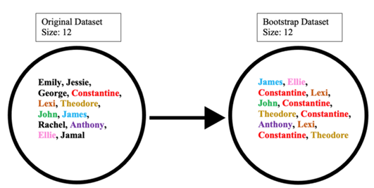

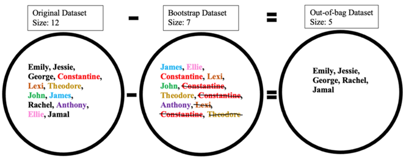

이미지 출처: https://en.wikipedia.org/wiki/Bootstrap_aggregating

부트스트랩(Bootstrap)을 통해 추출한 표본 집합들로 만들어진 모델들은 표본 집합들의 다양성으로 인해 다양한 결과를 내게되어 **앙상블 이론**에 따라

더 좋은 결과를 보이게 될 가능성이 높아집니다

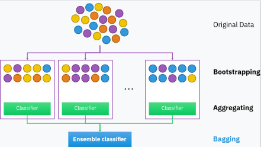

이미지 출처: https://en.wikipedia.org/wiki/Bootstrap_aggregating

#### OOB(Out-Of-Bag) 표본

부트스트랩(Bootstrap)에서 선택되지 않은 표본입니다.

- 학습에 사용이 되지 않았기 때문에, 기반 모델의 일반화 성능을 측정하는 목적으로 사용됩니다.

### 집계(Aggregation)

- 주로 여러 모델의 결과를 주로 평균을 내어 집계를 내어 출력을 만듭니다.

> $F_T(x) = \frac{1}{n}\sum_{t=1}^T f_t(x)$, $f_t$: t번 모델의 입력 (x)에 대한 출력 함수
- 집계(Aggregation) 연산은 순서성이 없으므로 학습 / 예측 과정의 **병렬화**가 가능합니다.
- 표본의 크기가 커질 수록 표본 평균의 분산이 줄어드는 것처럼, 앙상블 구성 모델의 수가 커질 수록, 모델의 분산은 줄어 드는 경향이 있습니다.

> 이러한 양상은 K-최근접 이웃 모델에서도 보입니다. 예측을 낼 때의 근접 이웃의 수 K를 늘릴 수록 모델의 분산이 줄고 편향이 커지는 것과 일맥상통합니다.

[Ex.1]

df_abalone을 80%는 학습데이터 df_train, 20%는 평가데이터 df_test로 나눕니다.

Rings를 예측하는 Bagging Regressor를 만듭니다.

입력 변수는 Age를 제외한 모든 변수를 사용하고, 성별(Sex)는 가변수화 합니다.

베이스 모델을 DecisionTreeRegressor로 합니다.

Bagging 모델의 수에 따라 분산을 측정하고 성능을 측정합니다. (1~100개)

df_train 모델로 학습을 하고, 분산을 측정합니다. df_test 모델로는 성능을 측정합니다.

성능 측정 지표는 평균제곱오차(MSE, Mean Squared Error)를 사용합니다.

```r
library(caret)

# 더미 변수 생성
dummies_model <- dummyVars(" ~ .", data = df_abalone)
df_abalone_dummies <- predict(dummies_model, newdata = df_abalone)
df_abalone_dummies <- as.data.frame(df_abalone_dummies)

# 데이터 분할
set.seed(123)
trainIndex <- createDataPartition(df_abalone_dummies$Rings, p = 0.8, list = FALSE)
df_train <- df_abalone_dummies[trainIndex, ]
df_test <- df_abalone_dummies[-trainIndex, ]

# X_cols 설정
X_cols <- setdiff(names(df_train), "Rings")

# 결과 확인
head(df_train)
```

|  | SexF | SexI | SexM | Length | Diameter | Height | Whole | Shucked | Viscera | Shell | Rings | no |
| --- | --- | --- | --- | --- | --- | --- | --- | --- | --- | --- | --- | --- |
| 1 | 0 | 0 | 1 | 0.455 | 0.365 | 0.095 | 0.5140 | 0.2245 | 0.1010 | 0.150 | 15 | 1 |
| 2 | 0 | 0 | 1 | 0.350 | 0.265 | 0.090 | 0.2255 | 0.0995 | 0.0485 | 0.070 | 7 | 2 |
| 4 | 0 | 0 | 1 | 0.440 | 0.365 | 0.125 | 0.5160 | 0.2155 | 0.1140 | 0.155 | 10 | 4 |
| 5 | 0 | 1 | 0 | 0.330 | 0.255 | 0.080 | 0.2050 | 0.0895 | 0.0395 | 0.055 | 7 | 5 |
| 7 | 1 | 0 | 0 | 0.530 | 0.415 | 0.150 | 0.7775 | 0.2370 | 0.1415 | 0.330 | 20 | 7 |
| 8 | 1 | 0 | 0 | 0.545 | 0.425 | 0.125 | 0.7680 | 0.2940 | 0.1495 | 0.260 | 16 | 8 |

```r
head(df_test)
```

|  | SexF | SexI | SexM | Length | Diameter | Height | Whole | Shucked | Viscera | Shell | Rings | no |
| --- | --- | --- | --- | --- | --- | --- | --- | --- | --- | --- | --- | --- |
| 3 | 1 | 0 | 0 | 0.530 | 0.42 | 0.135 | 0.6770 | 0.2565 | 0.1415 | 0.210 | 9 | 3 |
| 6 | 0 | 1 | 0 | 0.425 | 0.30 | 0.095 | 0.3515 | 0.1410 | 0.0775 | 0.120 | 8 | 6 |
| 9 | 0 | 0 | 1 | 0.475 | 0.37 | 0.125 | 0.5095 | 0.2165 | 0.1125 | 0.165 | 9 | 9 |
| 13 | 0 | 0 | 1 | 0.490 | 0.38 | 0.135 | 0.5415 | 0.2175 | 0.0950 | 0.190 | 11 | 13 |
| 20 | 0 | 0 | 1 | 0.450 | 0.32 | 0.100 | 0.3810 | 0.1705 | 0.0750 | 0.115 | 9 | 20 |
| 25 | 1 | 0 | 0 | 0.615 | 0.48 | 0.165 | 1.1615 | 0.5130 | 0.3010 | 0.305 | 10 | 25 |

```r
# Bootstrap 샘플링
set.seed(123)
df_bootstrap <- df_train[sample(nrow(df_train), replace = TRUE), ]

# 고유 인덱스 비율 계산
unique_indices_ratio <- length(unique(df_bootstrap$no)) / nrow(df_train)
unique_indices_ratio
```

```
[1] 0.636554
```

```r
library(rpart)
library(data.table)
# 부트스트랩 및 OOB 예측 수행
set.seed(123)
n_estimators_range <- 1:100
df_oob_prds <- list()
models <- list()

for (i in n_estimators_range) {
  df_bootstrap <- df_train[sample(nrow(df_train), replace = TRUE), ]  # Bootstrap
  oob_indices <- setdiff(df_train$no, unique(df_bootstrap$no))
  df_oob <- df_train[oob_indices, ]

  # 모델 학습
  reg_dt <- rpart(Rings ~ ., data = df_bootstrap[, c(X_cols, 'Rings')])
  models[[i]] <- reg_dt

  # OOB 예측
  df_oob_prds[[i]] <- data.frame(no = oob_indices, Prediction = predict(reg_dt, newdata = df_oob[, X_cols]), Tree = i)
}

# 예측 결과 결합
df_oob_prds_combined <- rbindlist(df_oob_prds)

# 데이터프레임으로 변환
df_oob_prds_combined <- as.data.frame(dcast(df_oob_prds_combined, no ~ Tree, value.var = "Prediction"))

# 예측 결과 확인
head(df_oob_prds_combined)
```

|  | no | 1 | 2 | 3 | 4 | 5 | 6 | 7 | 8 | 9 | 10 | 11 | 12 | 13 | 14 | 15 | 16 | 17 | 18 | 19 | 20 | 21 | 22 | 23 | 24 | 25 | 26 | 27 | 28 | … |
| --- | --- | --- | --- | --- | --- | --- | --- | --- | --- | --- | --- | --- | --- | --- | --- | --- | --- | --- | --- | --- | --- | --- | --- | --- | --- | --- | --- | --- | --- | --- |
| 1 | 1 | NA | NA | 10.376404 | NA | NA | NA | 9.094629 | NA | NA | NA | NA | 9.103125 | NA | 10.68254 | NA | NA | 8.908974 | NA | NA | NA | 9.133758 | NA | 8.945133 | NA | NA | NA | NA | NA | … |
| 2 | 2 | NA | NA | NA | NA | 9.249004 | NA | NA | 6.219626 | NA | NA | NA | 9.103125 | NA | NA | 9.078947 | 8.907357 | NA | NA | 7.408313 | 7.111498 | NA | NA | NA | NA | NA | NA | NA | 9.398406 | … |
| 3 | 4 | 6.301724 | NA | 6.747634 | NA | 7.715822 | NA | 5.437037 | NA | 7.14433 | NA | 7.743044 | NA | NA | 7.36166 | NA | NA | NA | 6.026471 | NA | 7.111498 | 5.618243 | NA | NA | NA | NA | 5.623693 | 7.057471 | NA | … |
| 4 | 5 | NA | NA | NA | 17.84211 | NA | 13.04573 | 12.516484 | NA | NA | 13.07905 | NA | NA | NA | NA | 12.656667 | NA | NA | NA | NA | NA | NA | NA | 13.023649 | NA | 13.41304 | NA | NA | NA | … |
| 5 | 7 | NA | 15.72611 | NA | NA | NA | NA | 12.516484 | NA | NA | 13.07905 | 11.207792 | NA | NA | 13.20000 | NA | NA | 12.866450 | NA | NA | NA | NA | NA | NA | 11.16304 | NA | 15.584337 | NA | 15.614458 | … |
| 6 | 8 | 13.166124 | NA | 13.321705 | 11.39884 | NA | 13.04573 | 12.516484 | NA | 12.95956 | 13.07905 | NA | 10.783784 | 13.09426 | NA | 12.656667 | 13.067485 | NA | 13.278146 | NA | NA | NA | NA | 13.023649 | NA | NA | 10.715517 | NA | NA | … |

```r
# OOB 평균 예측값 계산
oob_predictions <- rowMeans(df_oob_prds_combined[-1], na.rm = TRUE)  # 첫 열은 Index이므로 제외

# 실제 값과 비교하여 MSE 계산
actual_values <- df_train$Rings
s_oob_mse <- mean((actual_values - oob_predictions)^2)
s_oob_mse
```

```
[1] 14.58135
```

```r
# 모델 리스트를 순회하여 각 모델의 예측값을 데이터프레임으로 결합
df_train_prds <- do.call(cbind, lapply(seq_along(models), function(i) {
  pred <- predict(models[[i]], newdata = df_train[, X_cols])
  setNames(as.data.frame(pred), i)
}))
df_test_prds <- do.call(cbind, lapply(seq_along(models), function(i) {
  pred <- predict(models[[i]], newdata = df_test[, X_cols])
  setNames(as.data.frame(pred), i)
}))

# 열 이름 설정
colnames(df_train_prds) <- seq_along(models)
colnames(df_test_prds) <- seq_along(models)

# 결과 확인
head(df_train_prds)
```

|  | 1 | 2 | 3 | 4 | 5 | 6 | 7 | 8 | 9 | 10 | 11 | 12 | 13 | 14 | 15 | 16 | 17 | 18 | 19 | 20 | 21 | 22 | 23 | 24 | 25 | 26 | 27 | 28 | 29 | … |
| --- | --- | --- | --- | --- | --- | --- | --- | --- | --- | --- | --- | --- | --- | --- | --- | --- | --- | --- | --- | --- | --- | --- | --- | --- | --- | --- | --- | --- | --- | --- |
| 1 | 9.492837 | 9.104377 | 10.376404 | 9.010417 | 9.249004 | 9.720207 | 9.094629 | 9.881081 | 10.50980 | 9.236111 | 9.232365 | 9.103125 | 9.094311 | 10.68254 | 9.078947 | 8.907357 | 8.908974 | 9.303828 | 8.876712 | 10.348387 | 9.133758 | 9.201271 | 8.945133 | 10.19022 | 9.048921 | 9.911602 | 8.721957 | 9.398406 | 10.641026 | … |
| 2 | 6.301724 | 9.104377 | 6.747634 | 9.010417 | 9.249004 | 9.720207 | 9.094629 | 6.219626 | 7.14433 | 9.236111 | 7.743044 | 9.103125 | 7.359779 | 7.36166 | 9.078947 | 8.907357 | 7.436314 | 9.303828 | 7.408313 | 7.111498 | 9.133758 | 9.201271 | 7.560641 | 5.97000 | 7.395793 | 9.911602 | 7.057471 | 9.398406 | 7.282732 | … |
| 4 | 9.492837 | 12.387454 | 10.376404 | 11.398844 | 9.249004 | 9.720207 | 9.094629 | 9.881081 | 10.50980 | 9.236111 | 9.232365 | 9.103125 | 9.094311 | 10.68254 | 9.078947 | 8.907357 | 8.908974 | 9.303828 | 8.876712 | 10.348387 | 9.133758 | 9.201271 | 8.945133 | 10.19022 | 9.048921 | 9.911602 | 8.721957 | 9.398406 | 10.641026 | … |
| 5 | 6.301724 | 7.298387 | 6.747634 | 5.547794 | 7.715822 | 5.594059 | 5.437037 | 6.219626 | 7.14433 | 7.651361 | 7.743044 | 5.625442 | 7.359779 | 7.36166 | 7.621771 | 5.465278 | 5.617188 | 6.026471 | 5.551971 | 7.111498 | 5.618243 | 5.600733 | 5.563707 | 5.97000 | 7.395793 | 5.623693 | 7.057471 | 5.766102 | 7.282732 | … |
| 7 | 13.166124 | 15.726115 | 13.321705 | 17.842105 | 12.522167 | 13.045732 | 12.516484 | 12.897959 | 12.95956 | 13.079051 | 11.207792 | 15.856250 | 13.094262 | 13.20000 | 12.656667 | 13.067485 | 12.866450 | 13.278146 | 13.060284 | 11.774834 | 11.952632 | 13.221344 | 13.023649 | 11.16304 | 13.413043 | 15.584337 | 13.783883 | 15.614458 | 12.861538 | … |
| 8 | 13.166124 | 12.387454 | 13.321705 | 11.398844 | 12.522167 | 13.045732 | 12.516484 | 12.897959 | 12.95956 | 13.079051 | 11.207792 | 10.783784 | 13.094262 | 13.20000 | 12.656667 | 13.067485 | 12.866450 | 13.278146 | 13.060284 | 11.774834 | 11.952632 | 13.221344 | 13.023649 | 11.16304 | 13.413043 | 10.715517 | 13.783883 | 15.614458 | 12.861538 | … |

```r
head(df_test_prds)
```

|  | 1 | 2 | 3 | 4 | 5 | 6 | 7 | 8 | 9 | 10 | 11 | 12 | 13 | 14 | 15 | 16 | 17 | 18 | 19 | 20 | 21 | 22 | 23 | 24 | 25 | 26 | 27 | 28 | 29 | … |
| --- | --- | --- | --- | --- | --- | --- | --- | --- | --- | --- | --- | --- | --- | --- | --- | --- | --- | --- | --- | --- | --- | --- | --- | --- | --- | --- | --- | --- | --- | --- |
| 3 | 13.166124 | 12.387454 | 13.32171 | 11.398844 | 12.522167 | 13.045732 | 12.516484 | 12.897959 | 12.95956 | 13.079051 | 11.207792 | 10.783784 | 13.094262 | 13.20000 | 12.656667 | 13.067485 | 12.866450 | 13.278146 | 13.060284 | 11.77483 | 11.952632 | 13.221344 | 13.023649 | 11.16304 | 13.413043 | 10.715517 | 13.783883 | 11.329545 | 12.86154 | … |
| 6 | 7.900000 | 7.298387 | 10.37640 | 7.520080 | 7.715822 | 9.720207 | 7.505682 | 9.881081 | 10.50980 | 7.651361 | 7.743044 | 7.529637 | 9.094311 | 10.68254 | 7.621771 | 7.594324 | 8.908974 | 7.780797 | 8.876712 | 10.34839 | 7.662983 | 7.784127 | 8.945133 | 10.19022 | 9.048921 | 9.911602 | 8.721957 | 7.773551 | 10.64103 | … |
| 9 | 9.492837 | 12.387454 | 10.37640 | 11.398844 | 9.249004 | 9.720207 | 9.094629 | 9.881081 | 10.50980 | 9.236111 | 9.232365 | 10.783784 | 9.094311 | 10.68254 | 9.078947 | 8.907357 | 8.908974 | 9.303828 | 8.876712 | 10.34839 | 9.133758 | 9.201271 | 8.945133 | 10.19022 | 9.048921 | 9.911602 | 8.721957 | 9.398406 | 10.64103 | … |
| 13 | 13.166124 | 12.387454 | 13.32171 | 11.398844 | 12.522167 | 13.045732 | 12.516484 | 12.897959 | 12.95956 | 13.079051 | 11.207792 | 10.783784 | 13.094262 | 10.68254 | 12.656667 | 13.067485 | 12.866450 | 13.278146 | 13.060284 | 11.77483 | 11.952632 | 13.221344 | 13.023649 | 11.16304 | 9.048921 | 10.715517 | 13.783883 | 11.329545 | 12.86154 | … |
| 20 | 9.492837 | 9.104377 | 10.37640 | 9.010417 | 9.249004 | 9.720207 | 9.094629 | 9.881081 | 10.50980 | 9.236111 | 7.743044 | 9.103125 | 9.094311 | 10.68254 | 9.078947 | 8.907357 | 8.908974 | 9.303828 | 8.876712 | 10.34839 | 9.133758 | 9.201271 | 8.945133 | 10.19022 | 9.048921 | 9.911602 | 8.721957 | 9.398406 | 10.64103 | … |
| 25 | 13.166124 | 12.387454 | 13.32171 | 13.186992 | 15.675497 | 13.045732 | 12.516484 | 12.897959 | 12.95956 | 13.079051 | 11.207792 | 10.783784 | 13.094262 | 13.20000 | 12.656667 | 13.067485 | 12.866450 | 13.278146 | 13.060284 | 11.77483 | 11.952632 | 13.221344 | 13.023649 | 11.16304 | 13.413043 | 10.715517 | 13.783883 | 15.614458 | 12.86154 | … |

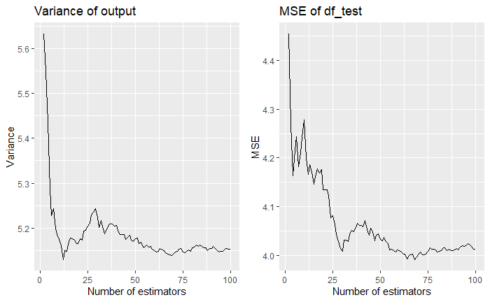

```r
# s_train_prd_var 계산
s_train_prd_var <- sapply(2:100, function(i) {
  apply(df_train_prds[, 1:i], 1, mean) %>% var()
})

# s_test_mse 계산
s_test_mse <- sapply(2:100, function(i) {
  mean((df_test$Rings - apply(df_test_prds[, 1:i], 1, mean))^2)
})

# 결과 시각화
df_results <- data.frame(
  Number_of_estimators = 2:100,
  Variance_of_output = s_train_prd_var,
  MSE_of_test = s_test_mse
)

# 두 개의 그래프를 함께 출력
p1 <- ggplot(df_results, aes(x = Number_of_estimators, y = Variance_of_output)) +
  geom_line() +
  ggtitle('Variance of output') +
  xlab('Number of estimators') +
  ylab('Variance')

p2 <- ggplot(df_results, aes(x = Number_of_estimators, y = MSE_of_test)) +
  geom_line() +
  ggtitle('MSE of df_test') +
  xlab('Number of estimators') +
  ylab('MSE')

# 그래프 출력
library(gridExtra)
grid.arrange(p1, p2, ncol = 2)
```

### 랜덤포레스트(RandomForest)

배깅 + 의사 결정 나무 입니다.

**[Ex.2]**

Ex.1에서 의사결절나무의 수와 리프노드의 최대 개수를 아래 리스트의 조합으로 설정하여 df_train의 분산, df_train과 df_test의 성능을 측정합니다.

n_estimators가 클수록 모델의 분산은 작아지고, max_leaf_nodes가 클수록 모델의 편향은 줄고 분산은 커집니다.

RandomForest 모델에서 Base 모델의 편향과 분산에 따른 경향을 살펴봅니다.

```python
n_estimators_list = [1, 3, 5, 10, 25, 50]
max_leaf_nodes_list = [4, 8, 16, 32, 64, 96, 128, 160, 192, 256, 384, 512]
```

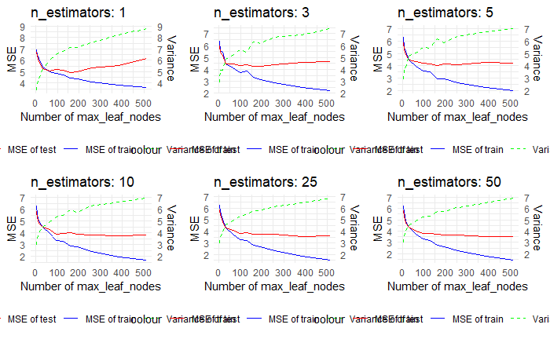

```r
library(randomForest)

# 파라미터 설정
n_estimators_list <- c(1, 3, 5, 10, 25, 50)
max_leaf_nodes_list <- c(4, 8, 16, 32, 64, 96, 128, 160, 192, 256, 384, 512)

mse_train <- list()
mse_test <- list()
prd_train_var <- list()

# 모델 학습 및 성능 측정
for (j in n_estimators_list) {
  mse_train[[as.character(j)]] <- numeric()
  mse_test[[as.character(j)]] <- numeric()
  prd_train_var[[as.character(j)]] <- numeric()
  for (i in max_leaf_nodes_list) {
    set.seed(123)
    reg_rf <- randomForest(Rings ~ ., data = df_train, ntree = j, maxnodes = i)

    prd_train <- predict(reg_rf, df_train)
    prd_test <- predict(reg_rf, df_test)

    mse_train[[as.character(j)]] <- c(mse_train[[as.character(j)]], mean((df_train$Rings - prd_train)^2))
    mse_test[[as.character(j)]] <- c(mse_test[[as.character(j)]], mean((df_test$Rings - prd_test)^2))
    prd_train_var[[as.character(j)]] <- c(prd_train_var[[as.character(j)]], var(prd_train))
  }
}

# 결과 시각화
plots <- list()
for (j in n_estimators_list) {
  df_plot <- data.frame(
    max_leaf_nodes = max_leaf_nodes_list,
    mse_train = mse_train[[as.character(j)]],
    mse_test = mse_test[[as.character(j)]],
    prd_train_var = prd_train_var[[as.character(j)]]
  )

  p <- ggplot(df_plot, aes(x = max_leaf_nodes)) +
    geom_line(aes(y = mse_train, color = "MSE of train")) +
    geom_line(aes(y = mse_test, color = "MSE of test")) +
    geom_line(aes(y = prd_train_var, color = "Variance of train"), linetype = "dashed") +
    scale_y_continuous(sec.axis = sec_axis(~ ., name = "Variance")) +
    labs(title = paste("n_estimators:", j), x = "Number of max_leaf_nodes", y = "MSE") +
    theme_minimal() +
    theme(legend.position = "bottom") +
    scale_color_manual(values = c("MSE of train" = "blue", "MSE of test" = "red", "Variance of train" = "green"))

  plots[[length(plots) + 1]] <- p
}

# 그래프 출력
grid.arrange(grobs = plots, ncol = 3)
```

## 부스팅(Boosting)

앙상블 모델을 수식으로 정리해 봅니다.

> $F_M(x) = \sum_{m=1}^Mf_m(x)$

> $f_m(x) = \alpha_th_m(x)$, $h_m(x)$: m번 모델의 출력 함수, $h_m$ m번째 모델, $\alpha_m$ 모델의 가중치

앙상블 모델의 학습는 손실을 최소로 하는 $F_M(x)$를 찾는 것입니다.

이를 수식으로 표현하면,

> $F_M(x) = argmin_FE_{x,y}[L(y, F(x))]$ 입니다. $L$: 손실 함수

하지만 최적의 $F_M(x)$ 한 번에 도출하는 것은 무척 풀기 어려운 문제입니다.

$F_M(x)$ 를 순차적인 과정을 통해 최적의 $F_M(x)$를 단계적으로 구성한 앙상블 모델이 바로 Boosting입니다.

이를 수식으로 표현하면,

> $F_m(x) = F_{m-1}(x) + \left(argmin_{\alpha_m, h_m}[\sum_{i=1}^nL(y_i, F_{m-1}(x_i) + \alpha_mh_m(x_i))]\right)(x)$
- $h_m(x)$는 주로 약한 학습기(Weak learner)를 사용합니다.

> Weak Learner: 주로 약한 성능을 지닌, 즉 편향이 높거나 분산이 낮은 모델입니다.
- 부스팅(Boosting) 기법은 기반 모델을 **순차적**으로 결합하여 점진적으로 예측 성능을 향상을 시킵니다.

> 점차적으로 모델의 편향이 낮아지고, 분산이 커집니다.

### AdaBoost(Adaptive Boosting)

$F_{m-1}(x)$ 모델의 각 학습 데이터 별 손실을 측정하여, 손실에 비례하여 학습 데이터에 가중치를 부여합니다.

$h_m(x)$ 모델을 데이터의 가중치에 따라 학습합니다.

$h_m(x)$을 $F_{m-1}(x)$과 더하여 $F_{m}(x)$을 만들 때의 $\alpha_m$은 $F_{m}(x)$의 손실이 최소가 되는 값을 취합니다.

#### 학습 알고리즘

1. 학습 데이터 가중치 $w_i, i= 1,...,n$ 을 $1/n$으로 초기화 합니다. m = 1로 초기화합니다. ($n$: 학습 데이터수)
2. 기반 모델 $h_m$을 학습 데이터을 가중치 w를 사용하여 학습을 시킵니다.
3. $F_{m}(x)$ 의 손실을 최소화하는 $\alpha_m$을 구합니다.

**[Ex]** 이진 분류 모델

모든 i,j에 대해 $h_j(x_i) \in \{-1, 1\}$ 이고, $y_i \in \{-1, 1\}$

$F_{m-1}(x_i) = \alpha_1h_1(x_i) + ... \alpha_{m-1}h_{m-1}(x_i)$

$F_{m}(x_i) = F_{m-1}(x_i) + \alpha_mh_m(x_i)$

데이터의 가중치에 따라 모델 $h_m(x)$를 학습하고, 최적의 $\alpha_i$를 구합니다.

여기에서는 Exponential loss 를 사용해봅니다.

> Exponential loss = $e^{-y_iF_{m}(x_i)}$, $y_i \in {-1, 1}, -\infty \le F_{m}(x_i) \le \infty$

Exponential loss는 계산이 간단합니다. 분류 오차가 클수록 손실이 현저하게 커지는 특징이 있습니다.

$E = \sum_{i=1}^N e^{-y_iF_m(x_i)} = \sum_{i=1}^N e^{-y_iF_{m-1}(x_i)}e^{-y_i\alpha_mh_m(x_i)}$

오차 $E$를 최소화하는 $\alpha_m$을 구합니다.

m 단계에서 i번째 표본의 가중치를 $w_i^{(m)}$로 정의합니다

> $w_i^{(m)} = e^{-y_iF_{m-1}(x_i)}$

표본 가중치 $w_i^{(m)}$에 따라 $h_m(x_i)$를 학습합니다.

> $E = \sum_{i=1}^N w_i^{(m)}e^{-y_i\alpha_mh_m(x_i)}$

여기서, $h_m(x_i)$가 맞을 경우는, $y_ih_m(x_i) = 1$, 틀릴 경우는 $y_ih_m(x_i) = -1$ 이 됩니다. 이에 따라 $E$를 정리하면,

> $E = \sum_{y_i=h_m(x_i)} w_i^{(m)}e^{-\alpha_m} + \sum_{y_i \ne h_m(x_i)} w_i^{(m)}e^{\alpha_m}$

$\frac{\partial{E}}{\partial{\alpha_m}} = 0$ 일 때, $E$의 값이 최소가 됩니다.

이를 풀어 정리하면,

$\alpha_m = \frac{1}{2}ln\left(\frac{\sum_{y_i=h_m(x_i)} w_i^{(m)}}{\sum_{y_i \ne h_m(x_i)} w_i^{(m)}}\right)$

이를 가중 오차율 (weighted error rate)로 나타냅니다.

$\epsilon_m = \sum_{y_i \ne h_m(x_i)} w_i^{(m)} / \sum_{i=1}^N w_i^{(m)}$

$\alpha_m = \frac{1}{2}ln\left(\frac{1 - \epsilon_m}{\epsilon_m}\right)$

4. $F_{m}(x_i) = F_{m-1}(x_i) + \alpha_mh_m(x_i)$ 으로 병합 시킵니다.
5. $w$를 $F_{m}(x)$의 손실로 업데이트 합니다.
6. $\sum_{i=1}^n{w_i} = 1$이 되도록 정규화 합니다.
7. m = m + 1, 종료 조건을 만족하지 않으면 2단계로 이동합니다.

**[Ex.4]**

n_estimators 수와 max_depth를 아래 리스트의 조합으로 설정하여 df_train의 분산, df_train과 df_test의 성능을 측정합니다.

n_estimators가 클수록 모델의 분산은 작아지고, max_depth가 클수록 모델의 편향은 줄고 분산은 커집니다.

AdaBoost 모델에서 Base 모델의 편향과 분산에 따른 경향을 살펴봅니다.

```python
n_estimators_list <- c(3, 5, 10, 25, 50)
max_depth_list <- c(2, 3, 4, 5, 6)
```

```r
library(ada)
library(rpart)
library(pROC)

# 데이터 분할
set.seed(123)
df_abalone$Class <- as.factor(ifelse(df_abalone$Sex == "I", -1, 1))
trainIndex <- createDataPartition(df_abalone$Class, p = 0.8, list = FALSE)
df_train <- df_abalone[trainIndex, ] %>% select(-Sex)
```

[output not shown]

[output not shown]

### Gradient boosting

$F_m(x) = F_{m-1}(x) + \left(argmin_{\alpha_m, h_m}[\sum_{i=1}^nL(y_i, F_{m-1}(x_i) + \alpha_mh_m(x_i))]\right)(x)$ 에서,

$L(y_i, F_{m-1}(x))$에 대한 $F_{m-1}$의 기울기를 구하고,

경사하강법처럼 기울기 차감하면 보다 손실이는 줄어드는 것에 착안합니다.

> $F_m(x) = F_{m-1}(x) - \alpha_m\sum_{i=1}^n \nabla_{F_{m-1}}L(y_i, F_{m-1}(x_i))$

$h_m(x_i)$와 $\alpha_i$를 구하는 문제를

$h_m(x_i)$가 기울기 $-\sum_{i=1}^n \nabla_{F_{m-1}}L(y_i, F_{m-1}(x_i))$ 학습하고,

손실의 차감을 최대화하는 $\alpha_m$를 찾는 것으로 바꿉니다.

이러한 앙상블 방법을 Gradient boosting이라고 합니다.

#### 학습 알고리즘

1. $F_0(x) = argmin_{const} \sum_{i=1}^n L(y_i, const)$, m = 1
2. $r_m = -\sum_{i=1}^n \nabla_{F_{m-1}}L(y_i, F_{m-1}(x_i))$ 기울기를 구합니다.

> $\nabla_{F_{m-1}}L(y_i, F_{m-1}(x_i)) = \left[ -\frac{\partial L(y_i, F(x_i))}{\partial F(x_i)} \right]_{F(x_i)=F_{m-1}(x_i)}$

**[Ex] $L(y_i, \hat{y_i}) = \frac{1}{2}(y_i - \hat{y_i})^2$, 회귀 모델**

$\frac{\partial L(y_i, F(x_i))}{\partial F(x_i)} = -(y_i - F(x_i))$

3. $r_m$을 대상 변수로 하고, $h_m(x)$를 학습 시킵니다.
4. $\alpha_m = argmin_\alpha \sum_{i=1}^n L(y_i, F_{m-1}(x_i) + \alpha h_m(x_i))$

> 보통 linear search를 사용합니다.
5. $F_{m}(x_i) = F_{m-1}(x_i) + \alpha_mh_m(x_i)$ 으로 병합시킵니다.
6. 종료 조건을 만족하지 않으면 2단계로 이동합니다.

**좀 더 직관적으로 표현하자면, 손실에 대한 출력값의 경사도를 맞추는 회귀 모델을 결합하는 과정입니다.**

**[Ex.5]**

n_estimators 수와 max_depth를 아래 리스트의 조합으로 설정하여 df_train의 분산, df_train과 df_test의 성능을 측정합니다.

n_estimators가 클수록 모델의 분산은 작아지고, max_depth가 클수록 모델의 편향은 줄고 분산은 커집니다.

```python
n_estimators_list <- c(3, 5, 10, 25, 50)
max_depth_list <- c(2, 3, 4, 5, 6)
```

```r
library(xgboost)

# 데이터 분할
set.seed(123)
df_abalone$Class <- ifelse(df_abalone$Sex == "I", 0, 1)
trainIndex <- createDataPartition(df_abalone$Class, p = 0.8, list = FALSE)
df_train <- df_abalone[trainIndex, ] %>% select(-Sex)
df_test <- df_abalone[-trainIndex, ] %>% select(-Sex)

# 열 이름 추출
X_cols <- colnames(df_train)[!(colnames(df_train) %in% c("Class", "Sex"))]

roc_train <- list()
roc_test <- list()
prd_train_var <- list()

# 파라미터 설정
n_estimators_list <- c(3, 5, 10, 25, 50)
max_depth_list <- c(2, 3, 4, 5, 6)

# 데이터 변환
dtrain <- xgb.DMatrix(data = as.matrix(df_train[, X_cols]), label = df_train$Class)
dtest <- xgb.DMatrix(data = as.matrix(df_test[, X_cols]), label = df_test$Class)

# 모델 학습 및 성능 측정
for (j in n_estimators_list) {
  roc_train[[as.character(j)]] <- numeric()
  roc_test[[as.character(j)]] <- numeric()
  prd_train_var[[as.character(j)]] <- numeric()
  for (i in max_depth_list) {
    set.seed(123)
    params <- list(
      objective = "binary:logistic",
      max_depth = i,
      eval_metric = "auc"
    )

    clf_xgb <- xgb.train(
      params = params,
      data = dtrain,
      nrounds = j,
      watchlist = list(train = dtrain, test = dtest),
      verbose = 0
    )

    prd_train <- predict(clf_xgb, newdata = dtrain)
    prd_test <- predict(clf_xgb, newdata = dtest)

    prd_train_var[[as.character(j)]] <- c(prd_train_var[[as.character(j)]], var(prd_train))
    roc_train[[as.character(j)]] <- c(roc_train[[as.character(j)]], roc(df_train$Class, prd_train, plot = FALSE)$auc)
    roc_test[[as.character(j)]] <- c(roc_test[[as.character(j)]], roc(df_test$Class, prd_test, plot = FALSE)$auc)
  }
}
# 결과 시각화
plots <- list()
for (j in n_estimators_list) {
  df_plot <- data.frame(
    max_depth = max_depth_list,
    roc_train = roc_train[[as.character(j)]],
    roc_test = roc_test[[as.character(j)]],
    prd_train_var = prd_train_var[[as.character(j)]]
  )

  p <- ggplot(df_plot, aes(x = max_depth)) +
    geom_line(aes(y = roc_train, color = "AUC of train")) +
    geom_line(aes(y = roc_test, color = "AUC of test")) +
    geom_line(aes(y = prd_train_var, color = "Variance of train"), linetype = "dashed") +
    scale_y_continuous(sec.axis = sec_axis(~ ., name = "Variance")) +
    labs(title = paste("n_estimators:", j), x = "Max Depth", y = "AUC") +
    theme_minimal() +
    theme(legend.position = "bottom") +
    scale_color_manual(values = c("AUC of train" = "blue", "AUC of test" = "red", "Variance of train" = "green"))

  plots[[length(plots) + 1]] <- p
}

# 그래프 출력
grid.arrange(grobs = plots, ncol = 3)
```

[output not shown]

## Voting

여러 종류의 모델을 결합하여, 각각의 모델이 지닌 단점을 서로 보완하여 일반 성능을 향상 시키는 방법입니다.

### Soft Voting vs Hard Voting

분류에서는 개별 모델을 종합하는 방법으로 Soft Voting과 Hard Voting이 있습니다.

- Soft Voting: 개별 모델의 예측확률의 평균이 가장 높은 클래스를 선택합니다.
- Hard Voting: 개별 모델의 예측한 클래스 중 가장 많을 것을 선택합니다.

**sklearn.ensemble.VotingClassifier, VotingRegressor**

**주요 하이퍼파라메터**

| 이름 | 설명 |
| --- | --- |
| estimators | (모델명, 모델 인스턴스)로 된 리스트 |
| weights | 모델별 가중치, None이면 동일 가중치가 적용됩니다. |
| voting | VotingClassifier만 유효합니다. ‘soft’ or ‘hard’ |

## 앙상블의 장단점

### 장점

- 여러 모델을 결합시켜 서로 단점을 보완하도록 구성함으로써 보다 성능이 좋을 모델을 만들 수 있습니다.
- 여러 모델의 결합은 출력의 분산을 줄여 주어, 과적합 현상을 완화 시킵니다.

### 단점

- 계산 비용 증가합니다
- 해석이 어려워집니다.
- Boosting은 모델의 결합과 동시에 대상 변수에 적합이 진행되므로, 과적합을 막기 위해서는 정교한 하이퍼 파라메터 최적화가 요구됩니다.